# DS220FinalProject

```python
import pandas as pd
import matplotlib.pyplot as plt
data = pd.read_csv("Real_Estate_Sales_2001-2021_GL.csv")
```

The dataset that I will be doing analyzing and retrieving data from will be real estate sales from 2001 to 2021. These are the listed sales that took place in September 30 to October 1 of every year from 2001-2021. The dataset includes useful information from which I will be querying from such as the listed year, data recorded for sale, the town it was listed in, the address, the assessed value, and the actual amount it sold for.

Questions to answer using this dataset.

1. List all rows that were sold for more than twice the assessed value, (sales ratio would be less than .5)
2. List the top 10 rows that have the highest rates of single family assessed value
3. List the top 10 rows that have the highest rates of single family actual sale value
4. List the top 10 addresses that have the highest differences among the sale amount and assessed value
5. List the top 10 addresses that have the lowest differences among the sale amount and assessed value
6. List the years and the amount of houses listed that year

The following code will name all of the columns of our dataset.

```python
data.columns
```

```
Index(['Serial Number', 'List Year', 'Date Recorded', 'Town', 'Address',
       'Assessed Value', 'Sale Amount', 'Sales Ratio', 'Property Type',
       'Residential Type', 'Non Use Code', 'Assessor Remarks', 'OPM remarks',
       'Location'],
      dtype='object')
```

I will now drop the non use code, assessor remarks, opm remarks, and location columns from the dataframe since I will not be using any information from them and it will clear up a lot of NaN values.

```python
data = data.drop(['Non Use Code','Assessor Remarks','OPM remarks','Location','Property Type'],axis = 'columns')
```

The following code will show the first 5 of the dataframe.

```python
data.head(5)
```

|  | Serial Number | List Year | Date Recorded | Town | Address | Assessed Value | Sale Amount | Sales Ratio | Residential Type |
| --- | --- | --- | --- | --- | --- | --- | --- | --- | --- |
| 0 | 2020348 | 2020 | 09/13/2021 | Ansonia | 230 WAKELEE AVE | 150500.0 | 325000.0 | 0.4630 | NaN |
| 1 | 20002 | 2020 | 10/02/2020 | Ashford | 390 TURNPIKE RD | 253000.0 | 430000.0 | 0.5883 | Single Family |
| 2 | 210317 | 2021 | 07/05/2022 | Avon | 53 COTSWOLD WAY | 329730.0 | 805000.0 | 0.4096 | Single Family |
| 3 | 200212 | 2020 | 03/09/2021 | Avon | 5 CHESTNUT DRIVE | 130400.0 | 179900.0 | 0.7248 | Condo |
| 4 | 200243 | 2020 | 04/13/2021 | Avon | 111 NORTHINGTON DRIVE | 619290.0 | 890000.0 | 0.6958 | Single Family |

The following code will show the last 5 of the dataframe.

```python
data.tail(5)
```

|  | Serial Number | List Year | Date Recorded | Town | Address | Assessed Value | Sale Amount | Sales Ratio | Residential Type |
| --- | --- | --- | --- | --- | --- | --- | --- | --- | --- |
| 621949 | 100308 | 2010 | 03/01/2011 | Danbury | 12-16 SCUPPO RD #K-78 | 129000.0 | 120000.0 | 1.075000 | Condo |
| 621950 | 90282 | 2009 | 09/28/2010 | Orange | 254 KAREN DR | 276600.0 | 370000.0 | 0.747568 | Single Family |
| 621951 | 90087 | 2009 | 09/10/2010 | Preston | 127 RIVER RD | 157800.0 | 150000.0 | 1.052000 | Single Family |
| 621952 | 10113 | 2010 | 03/15/2011 | Madison | 33 JEFFERSON PARK ROAD | 281300.0 | 275000.0 | 1.022909 | Single Family |
| 621953 | 10111 | 2010 | 12/28/2010 | Hamden | 115 ELMER AVE | 156380.0 | 23.0 | NaN | NaN |

The following code will check the number of rows and columns respectively.

```python
data.shape
```

```
(621954, 9)
```

I am going to check for null values in the following code. I will then drop all of the rows with naN values.

```python
data.isnull().sum()
```

```
Serial Number            0
List Year                0
Date Recorded            2
Town                     0
Address                 48
Assessed Value           0
Sale Amount              0
Sales Ratio              1
Residential Type    357467
dtype: int64
```

In the following code, I drop all of the null values and it will be inplace which means that the original dataframe will be updated.

```python
data.dropna(inplace = True)
data.isnull().sum()
```

```
Serial Number       0
List Year           0
Date Recorded       0
Town                0
Address             0
Assessed Value      0
Sale Amount         0
Sales Ratio         0
Residential Type    0
dtype: int64
```

I am going to check if there are any duplicated rows in the dataframe and there are not in this case.

```python
data.duplicated().sum()
```

```
0
```

In the following code, I am sorting the values according to the list year from 2006 to 2021.

```python
data.sort_values('List Year')
```

|  | Serial Number | List Year | Date Recorded | Town | Address | Assessed Value | Sale Amount | Sales Ratio | Residential Type |
| --- | --- | --- | --- | --- | --- | --- | --- | --- | --- |
| 476158 | 61828 | 2006 | 06/14/2007 | Bridgeport | 89 ELLSWORTH ST | 123649.0 | 300000.0 | 0.412163 | Condo |
| 460728 | 60201 | 2006 | 05/16/2007 | Derby | 126-128 DERBY AVE | 220850.0 | 65000.0 | 3.397692 | Single Family |
| 460725 | 60051 | 2006 | 10/31/2006 | Glastonbury | 222 WILLIAMS ST E UT 116 | 40300.0 | 91500.0 | 0.440437 | Condo |
| 460723 | 60358 | 2006 | 06/15/2007 | Cheshire | 50 COPPER BEECH DR | 381320.0 | 750000.0 | 0.508427 | Single Family |
| 460720 | 60310 | 2006 | 04/03/2007 | New Milford | 17 CORNWALL DRIVE | 244930.0 | 367000.0 | 0.667384 | Single Family |
| ... | ... | ... | ... | ... | ... | ... | ... | ... | ... |
| 89762 | 21038 | 2021 | 10/26/2021 | Bethel | 14 1/2 TOPSTONE DRIVE | 92190.0 | 210000.0 | 0.439000 | Condo |
| 89763 | 210614 | 2021 | 04/28/2022 | Fairfield | 237 TAUNTON ROAD | 414260.0 | 875000.0 | 0.473400 | Single Family |
| 89764 | 210031 | 2021 | 10/18/2021 | Glastonbury | 90 KONGSCUT VALLEY TRL | 462200.0 | 744900.0 | 0.620400 | Single Family |
| 89753 | 210272 | 2021 | 12/06/2021 | Bristol | 102 HOLLEY RD | 108360.0 | 195000.0 | 0.555600 | Single Family |
| 95754 | 2100830 | 2021 | 06/03/2022 | Stratford | 200 POST OAK ROAD | 182840.0 | 480224.0 | 0.380700 | Single Family |

264486 rows × 9 columns

In the following code, I will set the index for every row as its serial number since that is a unique value that was already assigned to it.

```python
data.set_index('Serial Number',inplace = True)
data
```

| Serial Number | List Year | Date Recorded | Town | Address | Assessed Value | Sale Amount | Sales Ratio | Residential Type |
| --- | --- | --- | --- | --- | --- | --- | --- | --- |
| 20002 | 2020 | 10/02/2020 | Ashford | 390 TURNPIKE RD | 253000.0 | 430000.0 | 0.588300 | Single Family |
| 210317 | 2021 | 07/05/2022 | Avon | 53 COTSWOLD WAY | 329730.0 | 805000.0 | 0.409600 | Single Family |
| 200212 | 2020 | 03/09/2021 | Avon | 5 CHESTNUT DRIVE | 130400.0 | 179900.0 | 0.724800 | Condo |
| 200243 | 2020 | 04/13/2021 | Avon | 111 NORTHINGTON DRIVE | 619290.0 | 890000.0 | 0.695800 | Single Family |
| 200377 | 2020 | 07/02/2021 | Avon | 70 FAR HILLS DRIVE | 862330.0 | 1447500.0 | 0.595700 | Single Family |
| ... | ... | ... | ... | ... | ... | ... | ... | ... |
| 100104 | 2010 | 04/01/2011 | Watertown | 22 PAXTON ST | 162700.0 | 155000.0 | 1.049677 | Single Family |
| 100308 | 2010 | 03/01/2011 | Danbury | 12-16 SCUPPO RD #K-78 | 129000.0 | 120000.0 | 1.075000 | Condo |
| 90282 | 2009 | 09/28/2010 | Orange | 254 KAREN DR | 276600.0 | 370000.0 | 0.747568 | Single Family |
| 90087 | 2009 | 09/10/2010 | Preston | 127 RIVER RD | 157800.0 | 150000.0 | 1.052000 | Single Family |
| 10113 | 2010 | 03/15/2011 | Madison | 33 JEFFERSON PARK ROAD | 281300.0 | 275000.0 | 1.022909 | Single Family |

264486 rows × 8 columns

**1. List all rows that were sold for more than twice the assessed value(sales ratio would be less than .5)**

The following code checks for sales ratio that is less than 0.5 and then displays a table that has the appropriate columns along with every row that has sales ratio less than 0.5.

```python
data[data['Sales Ratio']<.5][['List Year','Address','Town','Sales Ratio']]
```

| Serial Number | List Year | Address | Town | Sales Ratio |
| --- | --- | --- | --- | --- |
| 210317 | 2021 | 53 COTSWOLD WAY | Avon | 0.409600 |
| 210045 | 2021 | 89 LONG MEADOW RD | Bethlehem | 0.409100 |
| 200086 | 2020 | 39 WOODLAND RD | Bethlehem | 0.479800 |
| 210035 | 2021 | 25 QUARRY DOCK RD | Branford | 0.464500 |
| 211762 | 2021 | 38 RIVERVIEW DR | Bridgeport | 0.352100 |
| ... | ... | ... | ... | ... |
| 90792 | 2009 | 175 VINE ST | Hartford | 0.331169 |
| 90076 | 2009 | 33-35 LISBON ST | Hartford | 0.322667 |
| 90588 | 2009 | 133 GIRARD AV | Hartford | 0.209250 |
| 90042 | 2009 | 76 VILLAGE ST | Vernon | 0.322192 |
| 90101 | 2009 | 35 YALESVILLE SQUARE | Wallingford | 0.435152 |

68459 rows × 4 columns

**2. List the top 10 rows that have the highest rates of single family assessed value**

The following code finds only single family in residential types and then displays the appropriate columns which are sorted by the descending order of assessed value. The first 10 are shown since they are the top 10 rows.

```python
data[data['Residential Type']=='Single Family'][['List Year','Address','Town','Assessed Value','Residential Type']].sort_values('Assessed Value',ascending=False).head(10)
```

| Serial Number | List Year | Address | Town | Assessed Value | Residential Type |
| --- | --- | --- | --- | --- | --- |
| 10272 | 2010 | 642 NEWHALL ST | Hamden | 110670208.0 | Single Family |
| 21059 | 2021 | GREAT ISLAND ROAD LOT 22 | Darien | 35030100.0 | Single Family |
| 21058 | 2021 | GREAT ISLAND ROAD LOT 22 | Darien | 35030100.0 | Single Family |
| 20115 | 2020 | 22 & 27 CEDAR LANE | Sherman | 22235900.0 | Single Family |
| 60842 | 2006 | 110 FIELD POINT CIR | Greenwich | 21119910.0 | Single Family |
| 200505 | 2020 | 30 JOHN STREET | Greenwich | 19964630.0 | Single Family |
| 60946 | 2006 | STONYBROOK RD | Stratford | 19110000.0 | Single Family |
| 90582 | 2009 | 124 OLD MILL ROAD, GRW,CT 0683 | Greenwich | 17003280.0 | Single Family |
| 21079 | 2021 | 55 OLD QUARRY RD | Ridgefield | 16800000.0 | Single Family |
| 70084 | 2007 | 109 BYRAM SHORE RD | Greenwich | 16100000.0 | Single Family |

**3. List the top 10 rows that have the highest rates of single family actual sale value**

The following code finds only single family in residential types and then displays the appropriate columns which are sorted by the descending order of sale amount. The first 10 are shown since they are the top 10 rows.

```python
data[data['Residential Type']=='Single Family'][['List Year','Address','Town','Sale Amount','Residential Type']].sort_values('Sale Amount',ascending=False).head(10)
```

| Serial Number | List Year | Address | Town | Sale Amount | Residential Type |
| --- | --- | --- | --- | --- | --- |
| 20200078 | 2020 | 224 RIVER ROAD | Willington | 318790019.0 | Single Family |
| 200505 | 2020 | 30 JOHN STREET | Greenwich | 45000000.0 | Single Family |
| 21079 | 2021 | 55 OLD QUARRY RD | Ridgefield | 34420750.0 | Single Family |
| 90536 | 2009 | 30 JOHN STREET,GREENWICH,CT 06 | Greenwich | 31375000.0 | Single Family |
| 60596 | 2006 | 897 EAST ST | Middletown | 30830293.0 | Single Family |
| 70234 | 2007 | 30 JOHN ST | Greenwich | 30000000.0 | Single Family |
| 70252 | 2007 | 367 LUKES WOOD RD | New Canaan | 30000000.0 | Single Family |
| 70084 | 2007 | 109 BYRAM SHORE RD | Greenwich | 28423600.0 | Single Family |
| 60842 | 2006 | 110 FIELD POINT CIR | Greenwich | 25750000.0 | Single Family |
| 21125 | 2021 | 746 DANBURY RD | Ridgefield | 24345000.0 | Single Family |

**4. List the top 10 addresses that have the highest differences among the sale amount and assessed value**

The following code adds a new column 'Sales Difference' by finding the difference between 'Sales Amount' and 'Assessed Value'

```python
data['Sales Difference'] = data['Sale Amount'] - data['Assessed Value']
data
```

| Serial Number | List Year | Date Recorded | Town | Address | Assessed Value | Sale Amount | Sales Ratio | Residential Type | Sales Difference |
| --- | --- | --- | --- | --- | --- | --- | --- | --- | --- |
| 20002 | 2020 | 10/02/2020 | Ashford | 390 TURNPIKE RD | 253000.0 | 430000.0 | 0.588300 | Single Family | 177000.0 |
| 210317 | 2021 | 07/05/2022 | Avon | 53 COTSWOLD WAY | 329730.0 | 805000.0 | 0.409600 | Single Family | 475270.0 |
| 200212 | 2020 | 03/09/2021 | Avon | 5 CHESTNUT DRIVE | 130400.0 | 179900.0 | 0.724800 | Condo | 49500.0 |
| 200243 | 2020 | 04/13/2021 | Avon | 111 NORTHINGTON DRIVE | 619290.0 | 890000.0 | 0.695800 | Single Family | 270710.0 |
| 200377 | 2020 | 07/02/2021 | Avon | 70 FAR HILLS DRIVE | 862330.0 | 1447500.0 | 0.595700 | Single Family | 585170.0 |
| ... | ... | ... | ... | ... | ... | ... | ... | ... | ... |
| 100104 | 2010 | 04/01/2011 | Watertown | 22 PAXTON ST | 162700.0 | 155000.0 | 1.049677 | Single Family | -7700.0 |
| 100308 | 2010 | 03/01/2011 | Danbury | 12-16 SCUPPO RD #K-78 | 129000.0 | 120000.0 | 1.075000 | Condo | -9000.0 |
| 90282 | 2009 | 09/28/2010 | Orange | 254 KAREN DR | 276600.0 | 370000.0 | 0.747568 | Single Family | 93400.0 |
| 90087 | 2009 | 09/10/2010 | Preston | 127 RIVER RD | 157800.0 | 150000.0 | 1.052000 | Single Family | -7800.0 |
| 10113 | 2010 | 03/15/2011 | Madison | 33 JEFFERSON PARK ROAD | 281300.0 | 275000.0 | 1.022909 | Single Family | -6300.0 |

264486 rows × 9 columns

I will now make a new variable which will have the sales differences sorted in descending order and only the first 10 rows.

```python
top_10_address_highsalediff = data.sort_values('Sales Difference', ascending = False)[0:10].copy()
top_10_address_highsalediff
```

| Serial Number | List Year | Date Recorded | Town | Address | Assessed Value | Sale Amount | Sales Ratio | Residential Type | Sales Difference |
| --- | --- | --- | --- | --- | --- | --- | --- | --- | --- |
| 20200078 | 2020 | 07/06/2021 | Willington | 224 RIVER ROAD | 223070.0 | 318790019.0 | 0.000700 | Single Family | 318566949.0 |
| 20200102 | 2020 | 09/28/2021 | Willington | 7 TOLLAND TURNPIKE ROAD | 112040.0 | 194149073.0 | 0.000577 | Three Family | 194037033.0 |
| 2000798 | 2020 | 01/15/2021 | Stamford | 93 GLENBROOK ROAD GARAGE #2 | 6970.0 | 72000000.0 | 0.000000 | Condo | 71993030.0 |
| 2000797 | 2020 | 01/15/2021 | Stamford | 93 GLENBROOK ROAD GARAGE #3 | 9290.0 | 72000000.0 | 0.000100 | Condo | 71990710.0 |
| 2000808 | 2020 | 01/15/2021 | Stamford | 93 GLENBROOK ROAD #103 | 111240.0 | 72000000.0 | 0.001500 | Condo | 71888760.0 |
| 2000810 | 2020 | 01/15/2021 | Stamford | 93 GLENBROOK ROAD #105 | 111750.0 | 72000000.0 | 0.001500 | Condo | 71888250.0 |
| 2000818 | 2020 | 01/15/2021 | Stamford | 93 GLENBROOK ROAD #206 | 111800.0 | 72000000.0 | 0.001500 | Condo | 71888200.0 |
| 2000803 | 2020 | 01/15/2021 | Stamford | 93 GLENBROOK ROAD #209 | 114140.0 | 72000000.0 | 0.001500 | Condo | 71885860.0 |
| 2000809 | 2020 | 01/15/2021 | Stamford | 93 GLENBROOK ROAD #104 | 114470.0 | 72000000.0 | 0.001500 | Condo | 71885530.0 |
| 2000804 | 2020 | 01/15/2021 | Stamford | 93 GLENBROOK ROAD #210 | 114580.0 | 72000000.0 | 0.001500 | Condo | 71885420.0 |

I will now make a bar chart which will show the top 10 addresses that had the highest sales differences. It will along with it show the difference on the y-axis and the address on the x-axis.

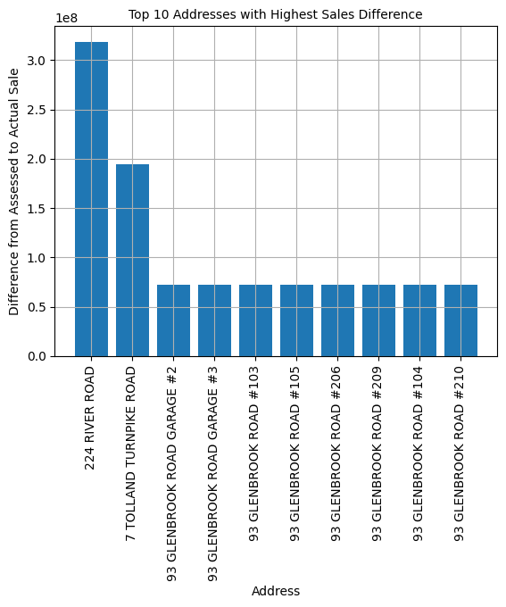

```python
topsalediff = top_10_address_highsalediff['Sales Difference']
addresses = list(top_10_address_highsalediff['Address'])
fig,ax = plt.subplots(nrows=1,ncols=1)
ax.bar(addresses,topsalediff)

plt.xlabel('Address',fontsize = 10)
plt.ylabel('Difference from Assessed to Actual Sale',fontsize = 10)
plt.xticks(rotation = 'vertical',fontsize = 10)
plt.title('Top 10 Addresses with Highest Sales Difference',fontsize = 10)

ax.grid()
plt.show()
```

**5. List the top 10 addresses that have the lowest differences among the sale amount and assessed value**

I will now make a new variable which will have the sales differences sorted in ascending order and only the first 10 rows.

```python
top_10_address_lowsalediff = data[data['Sales Difference']>0].sort_values('Sales Difference', ascending = True)[0:10].copy()
top_10_address_lowsalediff
```

| Serial Number | List Year | Date Recorded | Town | Address | Assessed Value | Sale Amount | Sales Ratio | Residential Type | Sales Difference |
| --- | --- | --- | --- | --- | --- | --- | --- | --- | --- |
| 900034 | 2009 | 06/15/2010 | Lisbon | 214 RIVER RD | 139890.0 | 139900.0 | 0.999929 | Single Family | 10.0 |
| 60191 | 2006 | 11/27/2006 | Bristol | 14 FAIRFIELD ST | 84980.0 | 85000.0 | 0.999765 | Single Family | 20.0 |
| 8408 | 2008 | 05/14/2009 | Meriden | 2-11 NORTHWOOD PL | 38980.0 | 39000.0 | 0.999487 | Condo | 20.0 |
| 900542 | 2009 | 05/27/2010 | Bristol | 87 BARBARA RD | 126980.0 | 127000.0 | 0.999843 | Single Family | 20.0 |
| 100318 | 2010 | 05/27/2011 | Enfield | 37 BRIDGE LA | 151970.0 | 152000.0 | 0.999803 | Single Family | 30.0 |
| 90231 | 2009 | 11/23/2009 | Bridgeport | 134 SOUNDVIEW AVENUE | 124970.0 | 125000.0 | 0.999760 | Single Family | 30.0 |
| 210624 | 2021 | 04/12/2022 | Hamden | 2696 WHITNEY AVE | 179970.0 | 180000.0 | 0.999800 | Two Family | 30.0 |
| 90487 | 2009 | 01/25/2010 | Bridgeport | 223-225 HAWLEY AVENUE | 139970.0 | 140000.0 | 0.999786 | Two Family | 30.0 |
| 210625 | 2021 | 04/12/2022 | Hamden | 2696 WHITNEY AVE | 179970.0 | 180000.0 | 0.999800 | Two Family | 30.0 |
| 60292 | 2006 | 01/29/2007 | West Haven | 51 OWNLY | 134960.0 | 135000.0 | 0.999704 | Single Family | 40.0 |

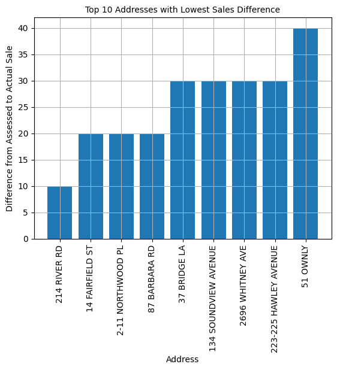

```python
topsalediff = top_10_address_lowsalediff['Sales Difference']
addresses = list(top_10_address_lowsalediff['Address'])
fig,ax = plt.subplots(nrows=1,ncols=1)
ax.bar(addresses,topsalediff)

plt.xlabel('Address',fontsize = 10)
plt.ylabel('Difference from Assessed to Actual Sale',fontsize = 10)
plt.xticks(rotation = 'vertical',fontsize = 10)
plt.title('Top 10 Addresses with Lowest Sales Difference',fontsize = 10)

ax.grid()
plt.show()
```

**6. List the years and the amount of houses listed that year**

In the following code, I make a new variable in which I find the counted values of the list year and sort them by descending order. I then create a new variable to create a dataframe for the past variable and rename the column to counted. In the end, this creates a new dataframe which has the list year and the amount of time it shows up.

```python
top_list_year = data['List Year'].value_counts().sort_values(ascending=False)
top_list_year1 = pd.DataFrame(top_list_year,columns = ['List Year'])
top_list_year1=top_list_year1.rename(columns={'List Year':'Counted'})
top_list_year1
```

|  | Counted |
| --- | --- |
| 2020 | 60728 |
| 2021 | 51371 |
| 2006 | 43290 |
| 2009 | 38769 |
| 2007 | 31827 |
| 2008 | 30104 |
| 2010 | 8135 |
| 2019 | 57 |
| 2018 | 41 |
| 2017 | 40 |
| 2016 | 31 |
| 2015 | 24 |
| 2012 | 20 |
| 2011 | 17 |
| 2014 | 17 |
| 2013 | 15 |

I will now make a bar chart which will show list years on the x-axis and the amount of listed on the y-axis. This will show all of the years and the list years to give an overview of the whole dataset.

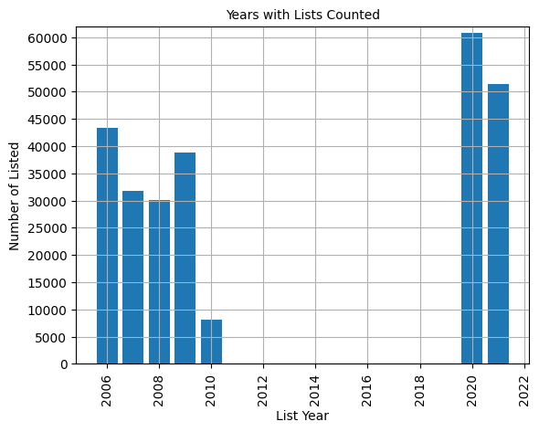

```python
import matplotlib.ticker as ticker

toplisted = top_list_year1['Counted']
listyear = list(top_list_year1.index)
fig,ax = plt.subplots(nrows=1,ncols=1)
ax.bar(listyear,toplisted)

plt.xlabel('List Year',fontsize = 10)
plt.ylabel('Number of Listed',fontsize = 10)
plt.xticks(rotation = 'vertical',fontsize = 10)
plt.title('Years with Lists Counted',fontsize = 10)
ax.yaxis.set_major_locator(ticker.MultipleLocator(5000))
plt.ylim(0, 62000)


ax.grid()
plt.show()
```